# Practice_Activity_Polynomial_Regression

```python
import pandas as pd
```

# Palmer Penguins Modeling

Import the Palmer Penguins dataset and print out the first few rows.

Suppose we want to predict `bill_depth_mm` using the other variables in the dataset.

Which variables would we need to **dummify**?

```python
# Code Here
%pip install palmerpenguins
from palmerpenguins import load_penguins

penguins = load_penguins()
```

```
Downloading palmerpenguins-0.1.4-py3-none-any.whl (17 kB)
```

```python
penguins.head()
# in order to predict bill_depth_mm we need to dummify species, island, sex, year
```

|  | species | island | bill_length_mm | bill_depth_mm | flipper_length_mm | body_mass_g | sex | year |
| --- | --- | --- | --- | --- | --- | --- | --- | --- |
| 0 | Adelie | Torgersen | 39.1 | 18.7 | 181.0 | 3750.0 | male | 2007 |
| 1 | Adelie | Torgersen | 39.5 | 17.4 | 186.0 | 3800.0 | female | 2007 |
| 2 | Adelie | Torgersen | 40.3 | 18.0 | 195.0 | 3250.0 | female | 2007 |
| 3 | Adelie | Torgersen | NaN | NaN | NaN | NaN | NaN | 2007 |
| 4 | Adelie | Torgersen | 36.7 | 19.3 | 193.0 | 3450.0 | female | 2007 |

```python
pd.get_dummies(penguins[['species', 'island', 'sex', 'year']])
```

|  | year | species_Adelie | species_Chinstrap | species_Gentoo | island_Biscoe | island_Dream | island_Torgersen | sex_female | sex_male |
| --- | --- | --- | --- | --- | --- | --- | --- | --- | --- |
| 0 | 2007 | True | False | False | False | False | True | False | True |
| 1 | 2007 | True | False | False | False | False | True | True | False |
| 2 | 2007 | True | False | False | False | False | True | True | False |
| 3 | 2007 | True | False | False | False | False | True | False | False |
| 4 | 2007 | True | False | False | False | False | True | True | False |
| ... | ... | ... | ... | ... | ... | ... | ... | ... | ... |
| 339 | 2009 | False | True | False | False | True | False | False | True |
| 340 | 2009 | False | True | False | False | True | False | True | False |
| 341 | 2009 | False | True | False | False | True | False | False | True |
| 342 | 2009 | False | True | False | False | True | False | False | True |
| 343 | 2009 | False | True | False | False | True | False | True | False |

344 rows × 9 columns

Why did we do this step?

Let’s use `bill_length_mm` to predict `bill_depth_mm`. Prepare your data and fit the following models on the entire dataset:

- Simple linear regression (e.g. straight-line) model
- Quadratic (degree 2 polynomial) model
- Cubic (degree 3 polynomial) model
- Degree 10 polynomial model

Make predictions for each model and plot your fitted models on the scatterplot.

```python
# I needed help from AI to transofrm the funciton to the new squared, cubed, and 10x squared functions
# Code Here
import numpy as np
import pandas as pd
import seaborn as sns
from sklearn.preprocessing import PolynomialFeatures
from sklearn.linear_model import LinearRegression
from plotnine import ggplot, aes, geom_point, geom_line, labs, theme_minimal
```

```python
penguins = sns.load_dataset("penguins")
penguins = penguins.dropna(subset=["bill_length_mm", "bill_depth_mm"])
```

```python
X = penguins[["bill_length_mm"]].values
y = penguins["bill_depth_mm"].values
```

```python
X_line = np.linspace(X.min(), X.max(), 200).reshape(-1, 1)
```

```python
def fit_poly(degree, label):
    poly = PolynomialFeatures(degree=degree)
    X_poly = poly.fit_transform(X)
    model = LinearRegression().fit(X_poly, y)
    y_line = model.predict(poly.transform(X_line))

    return pd.DataFrame({
        "bill_length_mm": X_line.flatten(),
        "bill_depth_mm": y_line,
        "model": label
    })
```

```python
df_linear = fit_poly(1, "Degree 1")
df_quad = fit_poly(2, "Degree 2")
df_cubic = fit_poly(3, "Degree 3")
df_deg10 = fit_poly(10, "Degree 10")
```

```python
curves = pd.concat([df_linear, df_quad, df_cubic, df_deg10])
```

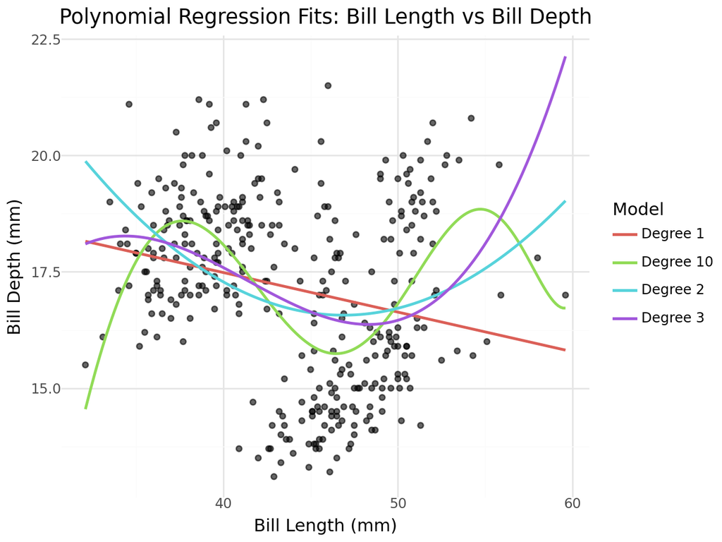

```python
plot = (
    ggplot(penguins, aes("bill_length_mm", "bill_depth_mm"))
    + geom_point(alpha=0.6)
    + geom_line(curves, aes(color="model"), size=1)
    + labs(
        title="Polynomial Regression Fits: Bill Length vs Bill Depth",
        x="Bill Length (mm)",
        y="Bill Depth (mm)",
        color="Model"
    )
    + theme_minimal()
)

plot
```

- Are any of the models above underfitting the data? If so, which ones and how can you tell?
- Are any of thhe models above overfitting the data? If so, which ones and how can you tell?
- Which of the above models do you think fits the data best and why?

The linear model, and the degree 2 model appear to be underfitting and missing trends where it should be picking them up. Whereas the variable 10x squared model seems to be overfitting and finding trends where there are none in the dataset. I can see this by (sorry I dont have a better term) the squiggli-ness of the lines and how well they appear to match to the dataset. I believe that the variable cubed (degree 3) model fits the data the best, this is because it follows the general trend of the data while not fitting perfectly (overfitting to the current dataset)